# Chapter 3: Linear regression

**Disclaimer!** I have had super busy week and unfortunately I did not have enough time to really focus this week and I am coding this last minute before deadline. So if and when i have made typos and silly mistakes, please be patient and I am sorry.

```r
date()
```

```
## [1] "Mon Nov 27 13:01:12 2023"
```

## Data

First step is to read the data created during the data wrangling part. In this case it is stored on my computer.

```r
alc=read.csv("C:/Users/03196349/Work Folders/PhD opinnot/IODS/IODS-project/data/alcdata.csv")
head(alc)
```

```
##   X school sex age address famsize Pstatus Medu Fedu     Mjob     Fjob
## 1 1     GP   F  18       U     GT3       A    4    4  at_home  teacher
## 2 2     GP   F  17       U     GT3       T    1    1  at_home    other
## 3 3     GP   F  15       U     LE3       T    1    1  at_home    other
## 4 4     GP   F  15       U     GT3       T    4    2   health services
## 5 5     GP   F  16       U     GT3       T    3    3    other    other
## 6 6     GP   M  16       U     LE3       T    4    3 services    other
##       reason guardian traveltime studytime schoolsup famsup activities nursery
## 1     course   mother          2         2       yes     no         no     yes
## 2     course   father          1         2        no    yes         no      no
## 3      other   mother          1         2       yes     no         no     yes
## 4       home   mother          1         3        no    yes        yes     yes
## 5       home   father          1         2        no    yes         no     yes
## 6 reputation   mother          1         2        no    yes        yes     yes
##   higher internet romantic famrel freetime goout Dalc Walc health failures paid
## 1    yes       no       no      4        3     4    1    1      3        0   no
## 2    yes      yes       no      5        3     3    1    1      3        0   no
## 3    yes      yes       no      4        3     2    2    3      3        2  yes
## 4    yes      yes      yes      3        2     2    1    1      5        0  yes
## 5    yes       no       no      4        3     2    1    2      5        0  yes
## 6    yes      yes       no      5        4     2    1    2      5        0  yes
##   absences G1 G2 G3 alc_use high_use
## 1        5  2  8  8     1.0    FALSE
## 2        3  7  8  8     1.0    FALSE
## 3        8 10 10 11     2.5     TRUE
## 4        1 14 14 14     1.0    FALSE
## 5        2  8 12 12     1.5    FALSE
## 6        8 14 14 14     1.5    FALSE
```

Let’s remove the first column “x” as it is duplicate of row numbers

```r
alc=alc[,-1]
```

Let’s take a look on our data

```r
colnames(alc)
```

```
##  [1] "school"     "sex"        "age"        "address"    "famsize"
##  [6] "Pstatus"    "Medu"       "Fedu"       "Mjob"       "Fjob"
## [11] "reason"     "guardian"   "traveltime" "studytime"  "schoolsup"
## [16] "famsup"     "activities" "nursery"    "higher"     "internet"
## [21] "romantic"   "famrel"     "freetime"   "goout"      "Dalc"
## [26] "Walc"       "health"     "failures"   "paid"       "absences"
## [31] "G1"         "G2"         "G3"         "alc_use"    "high_use"
```

We have 35 columns describing information about students. Some variables describe background information. Variables G1, G2 and G3 decribes the grades of testsubjects. Alc_use tells how large is alcohol consumption and high use tells whether the consumption is high or not.

The 4 variables i would like to choose are absence, G3, pstatus and age. I assume that high absence, low grades, broken families and older age is linked to high consumption of alcohol.

First I would like to check how those variables are related to each other. But before that, let’s instal some packages!

```r
library(tidyr); library(dplyr); library(ggplot2)
table(alc$Pstatus, alc$high_use)
```

```
##
##     FALSE TRUE
##   A    26   12
##   T   233   99
```

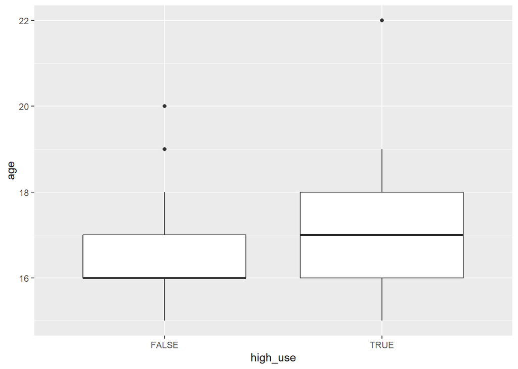

```r
g1 <- ggplot(alc, aes(x = high_use, y = age))
g2 <- ggplot(alc, aes(x = high_use, y = G3))
g3 <- ggplot(alc, aes(x = high_use, y = absences))


g1 + geom_boxplot()
```

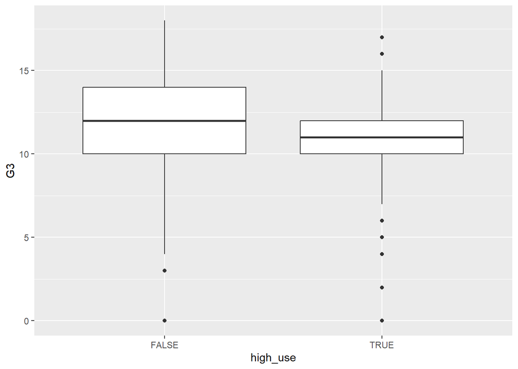

```r
g2 + geom_boxplot()
```

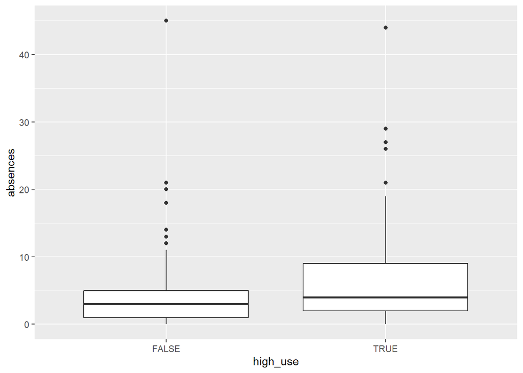

```r
g3 + geom_boxplot()
```

Using tables and boxplots we can assume

- high consumption of alcohol is slightly more common in broken families
- Young people use less alcohol
- People with high grades have smaller alcohol consumption
- people with high alcohol consumption are more often absence

Therefore hypotheses presented seem to be correct.

```r
m <- glm(high_use ~ G3 + absences + age + Pstatus, data = alc, family = "binomial")
summary(m)
```

```
##
## Call:
## glm(formula = high_use ~ G3 + absences + age + Pstatus, family = "binomial",
##     data = alc)
##
## Deviance Residuals:
##     Min       1Q   Median       3Q      Max
## -2.3352  -0.8239  -0.7050   1.2037   1.8781
##
## Coefficients:
##             Estimate Std. Error z value Pr(>|z|)
## (Intercept) -2.52154    1.82438  -1.382 0.166931
## G3          -0.06845    0.03602  -1.900 0.057371 .
## absences     0.08199    0.02335   3.511 0.000446 ***
## age          0.12084    0.10147   1.191 0.233666
## PstatusT     0.05517    0.39732   0.139 0.889572
## ---
## Signif. codes:  0 '***' 0.001 '**' 0.01 '*' 0.05 '.' 0.1 ' ' 1
##
## (Dispersion parameter for binomial family taken to be 1)
##
##     Null deviance: 452.04  on 369  degrees of freedom
## Residual deviance: 428.47  on 365  degrees of freedom
## AIC: 438.47
##
## Number of Fisher Scoring iterations: 4
```

```r
step(m)
```

```
## Start:  AIC=438.47
## high_use ~ G3 + absences + age + Pstatus
##
##            Df Deviance    AIC
## - Pstatus   1   428.49 436.49
## - age       1   429.89 437.89
## <none>          428.47 438.47
## - G3        1   432.09 440.09
## - absences  1   442.85 450.85
##
## Step:  AIC=436.49
## high_use ~ G3 + absences + age
##
##            Df Deviance    AIC
## - age       1   429.93 435.93
## <none>          428.49 436.49
## - G3        1   432.17 438.17
## - absences  1   443.07 449.07
##
## Step:  AIC=435.93
## high_use ~ G3 + absences
##
##            Df Deviance    AIC
## <none>          429.93 435.93
## - G3        1   434.52 438.52
## - absences  1   445.68 449.68
```

```
##
## Call:  glm(formula = high_use ~ G3 + absences, family = "binomial",
##     data = alc)
##
## Coefficients:
## (Intercept)           G3     absences
##    -0.38732     -0.07606      0.08423
##
## Degrees of Freedom: 369 Total (i.e. Null);  367 Residual
## Null Deviance:       452
## Residual Deviance: 429.9     AIC: 435.9
```

In this case such model would have just 2 predictors: *absence and G3*. So let’s create such model.

```r
m <- glm(high_use ~ G3 + absences, data = alc, family = "binomial")
summary(m)
```

```
##
## Call:
## glm(formula = high_use ~ G3 + absences, family = "binomial",
##     data = alc)
##
## Deviance Residuals:
##     Min       1Q   Median       3Q      Max
## -2.3286  -0.8298  -0.7219   1.2113   1.9242
##
## Coefficients:
##             Estimate Std. Error z value Pr(>|z|)
## (Intercept) -0.38732    0.43500  -0.890 0.373259
## G3          -0.07606    0.03553  -2.141 0.032311 *
## absences     0.08423    0.02309   3.648 0.000264 ***
## ---
## Signif. codes:  0 '***' 0.001 '**' 0.01 '*' 0.05 '.' 0.1 ' ' 1
##
## (Dispersion parameter for binomial family taken to be 1)
##
##     Null deviance: 452.04  on 369  degrees of freedom
## Residual deviance: 429.93  on 367  degrees of freedom
## AIC: 435.93
##
## Number of Fisher Scoring iterations: 4
```

So according to he model the astimate for parameter G3 is -0.08, and parameter for absence is 0.084. intercept is -0.39. To calculate odds ratios, we use following command:

```r
OR <- coef(m) %>% exp
OR
```

```
## (Intercept)          G3    absences
##   0.6788751   0.9267616   1.0878762
```

Ratios describe the change of predictable variable if the explainable variable is changed one unit.

```r
CI=confint(m)
CI
```

```
##                   2.5 %       97.5 %
## (Intercept) -1.25260555  0.459482521
## G3          -0.14621889 -0.006471056
## absences     0.04110528  0.131708308
```

This provides 95% confidence intervals. 97.5 being the upper and 2.5 the lower interval.

Hypothesis vise this would mean that age and family status does not have important role on does one consume high amounts of alcohol or not. And that high grades means less alcohol and hing absences is tied to high alcohol consumption. How eve it is unclear which one is the cause and which is the result.

```r
alc = mutate(alc, probability = predict(m, type = "response"))
alc = mutate(alc, prediction =probability>0.5)
table(high_use = alc$high_use, prediction = alc$prediction)%>%prop.table()
```

```
##         prediction
## high_use      FALSE       TRUE
##    FALSE 0.68108108 0.01891892
##    TRUE  0.25675676 0.04324324
```

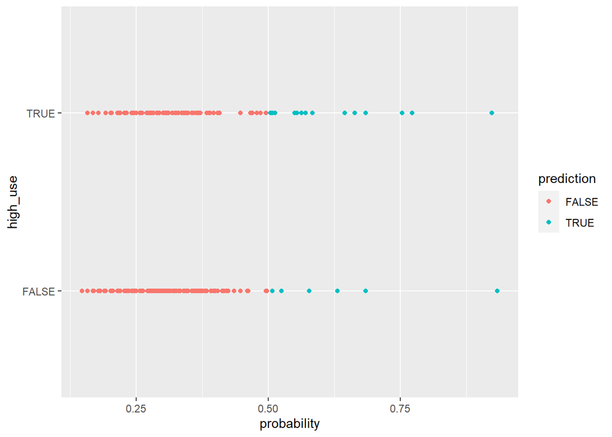

```r
g <- ggplot(alc, aes(x = probability, y = high_use, col=prediction))

# define the geom as points and draw the plot
g+geom_point()
```

The visual representation shows that the model often assumes High use to be false even tough it actually would be true.

```r
loss_func <- function(class, prob) {
  n_wrong <- abs(class - prob) > 0.5
  mean(n_wrong)
}

loss_func(alc$high_use,alc$probability)
```

```
## [1] 0.2756757
```

The training error (the mean number of wrong predictions) is 0,28

```r
library(boot)
cv <- cv.glm(data = alc, cost = loss_func, glmfit = m, K = 10)

# average number of wrong predictions in the cross validation
cv$delta[1]
```

```
## [1] 0.2837838
```

```r
m2 <- glm(high_use ~ G3 + absences+ school + sex + address+ famsize + Pstatus + Medu + Fedu + Mjob + Fjob + reason + guardian + traveltime + studytime + schoolsup+ famsup+ activities + nursery + higher + internet + romantic + famrel + freetime + goout + health + failures + paid + absences + G1 + G2, data = alc, family = "binomial")
summary(m2)
```

```
##
## Call:
## glm(formula = high_use ~ G3 + absences + school + sex + address +
##     famsize + Pstatus + Medu + Fedu + Mjob + Fjob + reason +
##     guardian + traveltime + studytime + schoolsup + famsup +
##     activities + nursery + higher + internet + romantic + famrel +
##     freetime + goout + health + failures + paid + absences +
##     G1 + G2, family = "binomial", data = alc)
##
## Deviance Residuals:
##     Min       1Q   Median       3Q      Max
## -1.7620  -0.6544  -0.3590   0.4831   2.8990
##
## Coefficients:
##                  Estimate Std. Error z value Pr(>|z|)
## (Intercept)      -3.10711    1.79919  -1.727 0.084177 .
## G3                0.05976    0.11463   0.521 0.602121
## absences          0.09105    0.02706   3.365 0.000766 ***
## schoolMS         -0.48058    0.53496  -0.898 0.369001
## sexM              0.84885    0.33281   2.551 0.010755 *
## addressU         -0.85479    0.41943  -2.038 0.041552 *
## famsizeLE3        0.51405    0.33078   1.554 0.120176
## PstatusT         -0.29228    0.53799  -0.543 0.586937
## Medu              0.04021    0.22256   0.181 0.856645
## Fedu              0.14434    0.19799   0.729 0.465991
## Mjobhealth       -1.07147    0.76687  -1.397 0.162353
## Mjobother        -0.85282    0.50337  -1.694 0.090222 .
## Mjobservices     -0.82754    0.58036  -1.426 0.153896
## Mjobteacher      -0.34813    0.70825  -0.492 0.623052
## Fjobhealth        0.33260    1.19154   0.279 0.780142
## Fjobother         0.81603    0.86311   0.945 0.344431
## Fjobservices      1.19959    0.88620   1.354 0.175853
## Fjobteacher      -0.34774    1.04522  -0.333 0.739367
## reasonhome        0.55292    0.39470   1.401 0.161262
## reasonother       1.52294    0.54867   2.776 0.005508 **
## reasonreputation  0.01215    0.41787   0.029 0.976799
## guardianmother   -0.83744    0.37652  -2.224 0.026136 *
## guardianother    -0.13975    0.80413  -0.174 0.862026
## traveltime        0.32446    0.24022   1.351 0.176797
## studytime        -0.27488    0.20833  -1.319 0.187012
```

[output cut: 10 more lines]

```
## health            0.18851    0.11495   1.640 0.101042
## failures          0.33167    0.27916   1.188 0.234790
## paidyes           0.53225    0.32442   1.641 0.100883
## G1               -0.13568    0.12864  -1.055 0.291563
## G2                0.10089    0.15969   0.632 0.527532
## ---
## Signif. codes:  0 '***' 0.001 '**' 0.01 '*' 0.05 '.' 0.1 ' ' 1
##
## (Dispersion parameter for binomial family taken to be 1)
##
##     Null deviance: 452.04  on 369  degrees of freedom
## Residual deviance: 310.30  on 330  degrees of freedom
## AIC: 390.3
##
## Number of Fisher Scoring iterations: 5
```

```r
step(m2)
```

```
## Start:  AIC=390.3
## high_use ~ G3 + absences + school + sex + address + famsize +
##     Pstatus + Medu + Fedu + Mjob + Fjob + reason + guardian +
##     traveltime + studytime + schoolsup + famsup + activities +
##     nursery + higher + internet + romantic + famrel + freetime +
##     goout + health + failures + paid + absences + G1 + G2
##
##              Df Deviance    AIC
## - Mjob        4   314.58 386.58
## - schoolsup   1   310.30 388.30
## - Medu        1   310.33 388.33
## - internet    1   310.34 388.34
## - famsup      1   310.35 388.35
## - higher      1   310.47 388.47
## - G3          1   310.57 388.57
## - Pstatus     1   310.59 388.59
## - G2          1   310.70 388.70
## - Fedu        1   310.83 388.83
## - Fjob        4   317.06 389.06
## - school      1   311.12 389.12
## - G1          1   311.40 389.40
## - failures    1   311.73 389.73
## - nursery     1   311.99 389.99
## - studytime   1   312.08 390.08
## - romantic    1   312.11 390.11
## - traveltime  1   312.14 390.14
## <none>            310.30 390.30
## - famsize     1   312.70 390.70
## - paid        1   313.03 391.03
## - health      1   313.05 391.05
## - freetime    1   313.44 391.44
## - guardian    2   315.67 391.67
## - activities  1   313.75 391.75
## - address     1   314.45 392.45
## - reason      3   319.54 393.54
## - sex         1   316.96 394.96
## - absences    1   321.59 399.59
## - famrel      1   322.20 400.20
## - goout       1   350.56 428.56
##
```

[output cut: 492 more lines]

```
##              Df Deviance    AIC
## <none>            329.01 363.01
## - famsize     1   331.20 363.20
## - romantic    1   331.25 363.25
## - reason      3   335.60 363.60
## - activities  1   331.61 363.61
## - health      1   331.97 363.97
## - studytime   1   332.12 364.12
## - paid        1   332.59 364.59
## - guardian    2   335.95 365.95
## - address     1   336.70 368.70
## - sex         1   338.10 370.10
## - famrel      1   338.76 370.76
## - absences    1   343.00 375.00
## - goout       1   382.34 414.34
```

```
##
## Call:  glm(formula = high_use ~ absences + sex + address + famsize +
##     reason + guardian + studytime + activities + romantic + famrel +
##     goout + health + paid, family = "binomial", data = alc)
##
## Coefficients:
##      (Intercept)          absences              sexM          addressU
##         -1.72681           0.09174           0.91034          -0.94771
##       famsizeLE3        reasonhome       reasonother  reasonreputation
##          0.45183           0.20790           1.02210          -0.27714
##   guardianmother     guardianother         studytime     activitiesyes
##         -0.75088           0.40855          -0.32528          -0.46361
##      romanticyes            famrel             goout            health
##         -0.45457          -0.48800           0.90858           0.17681
##          paidyes
##          0.54838
##
## Degrees of Freedom: 369 Total (i.e. Null);  353 Residual
## Null Deviance:       452
## Residual Deviance: 329   AIC: 363
```

```r
m3 <- glm(high_use ~ absences + sex + address + famsize +
    reason + guardian + studytime + activities + romantic + famrel +
    goout + health + paid, data = alc, family = "binomial")
summary(m3)
```

```
##
## Call:
## glm(formula = high_use ~ absences + sex + address + famsize +
##     reason + guardian + studytime + activities + romantic + famrel +
##     goout + health + paid, family = "binomial", data = alc)
##
## Deviance Residuals:
##     Min       1Q   Median       3Q      Max
## -1.8674  -0.7171  -0.4029   0.5821   2.7665
##
## Coefficients:
##                  Estimate Std. Error z value Pr(>|z|)
## (Intercept)      -1.72681    0.94633  -1.825 0.068041 .
## absences          0.09174    0.02432   3.773 0.000161 ***
## sexM              0.91034    0.30568   2.978 0.002901 **
## addressU         -0.94771    0.34320  -2.761 0.005756 **
## famsizeLE3        0.45183    0.30426   1.485 0.137536
## reasonhome        0.20790    0.36585   0.568 0.569858
## reasonother       1.02210    0.48846   2.093 0.036393 *
## reasonreputation -0.27714    0.37752  -0.734 0.462877
## guardianmother   -0.75088    0.33290  -2.256 0.024096 *
## guardianother     0.40855    0.73349   0.557 0.577533
## studytime        -0.32528    0.18830  -1.727 0.084081 .
## activitiesyes    -0.46361    0.28927  -1.603 0.109002
## romanticyes      -0.45457    0.30736  -1.479 0.139160
## famrel           -0.48800    0.15813  -3.086 0.002028 **
## goout             0.90858    0.13835   6.567 5.13e-11 ***
## health            0.17681    0.10399   1.700 0.089096 .
## paidyes           0.54838    0.29252   1.875 0.060834 .
## ---
## Signif. codes:  0 '***' 0.001 '**' 0.01 '*' 0.05 '.' 0.1 ' ' 1
##
## (Dispersion parameter for binomial family taken to be 1)
##
##     Null deviance: 452.04  on 369  degrees of freedom
## Residual deviance: 329.01  on 353  degrees of freedom
## AIC: 363.01
##
## Number of Fisher Scoring iterations: 5
```

```r
alc2 = mutate(alc, probability = predict(m3, type = "response"))
alc = mutate(alc, prediction =probability>0.5)
loss_func <- function(class, prob) {
  n_wrong <- abs(class - prob) > 0.5
  mean(n_wrong)
}
loss_func(alc$high_use,alc$probability)
```

```
## [1] 0.2756757
```

```r
cv <- cv.glm(data = alc, cost = loss_func, glmfit = m, K = 10)
cv$delta[1]
```

```
## [1] 0.2864865
```

**Disclaimer!** I have had super busy week and unfortunately I did not have enough time to really focus this week and I am coding this last minute before deadline. So if and when i have made typos and silly mistakes, please be patient and I am sorry.

```r
date()
```

```
## [1] "Mon Nov 27 13:01:16 2023"
```

## Data

First step is to read the data created during the data wrangling part. In this case it is stored on my computer.

```r
alc=read.csv("C:/Users/03196349/Work Folders/PhD opinnot/IODS/IODS-project/data/alcdata.csv")
head(alc)
```

```
##   X school sex age address famsize Pstatus Medu Fedu     Mjob     Fjob
## 1 1     GP   F  18       U     GT3       A    4    4  at_home  teacher
## 2 2     GP   F  17       U     GT3       T    1    1  at_home    other
## 3 3     GP   F  15       U     LE3       T    1    1  at_home    other
## 4 4     GP   F  15       U     GT3       T    4    2   health services
## 5 5     GP   F  16       U     GT3       T    3    3    other    other
## 6 6     GP   M  16       U     LE3       T    4    3 services    other
##       reason guardian traveltime studytime schoolsup famsup activities nursery
## 1     course   mother          2         2       yes     no         no     yes
## 2     course   father          1         2        no    yes         no      no
## 3      other   mother          1         2       yes     no         no     yes
## 4       home   mother          1         3        no    yes        yes     yes
## 5       home   father          1         2        no    yes         no     yes
## 6 reputation   mother          1         2        no    yes        yes     yes
##   higher internet romantic famrel freetime goout Dalc Walc health failures paid
## 1    yes       no       no      4        3     4    1    1      3        0   no
## 2    yes      yes       no      5        3     3    1    1      3        0   no
## 3    yes      yes       no      4        3     2    2    3      3        2  yes
## 4    yes      yes      yes      3        2     2    1    1      5        0  yes
## 5    yes       no       no      4        3     2    1    2      5        0  yes
## 6    yes      yes       no      5        4     2    1    2      5        0  yes
##   absences G1 G2 G3 alc_use high_use
## 1        5  2  8  8     1.0    FALSE
## 2        3  7  8  8     1.0    FALSE
## 3        8 10 10 11     2.5     TRUE
## 4        1 14 14 14     1.0    FALSE
## 5        2  8 12 12     1.5    FALSE
## 6        8 14 14 14     1.5    FALSE
```

Let’s remove the first column “x” as it is duplicate of row numbers

```r
alc=alc[,-1]
```

Let’s take a look on our data

```r
colnames(alc)
```

```
##  [1] "school"     "sex"        "age"        "address"    "famsize"
##  [6] "Pstatus"    "Medu"       "Fedu"       "Mjob"       "Fjob"
## [11] "reason"     "guardian"   "traveltime" "studytime"  "schoolsup"
## [16] "famsup"     "activities" "nursery"    "higher"     "internet"
## [21] "romantic"   "famrel"     "freetime"   "goout"      "Dalc"
## [26] "Walc"       "health"     "failures"   "paid"       "absences"
## [31] "G1"         "G2"         "G3"         "alc_use"    "high_use"
```

We have 35 columns describing information about students. Some variables describe background information. Variables G1, G2 and G3 decribes the grades of testsubjects. Alc_use tells how large is alcohol consumption and high use tells whether the consumption is high or not.

The 4 variables i would like to choose are absence, G3, pstatus and age. I assume that high absence, low grades, broken families and older age is linked to high consumption of alcohol.

First I would like to check how those variables are related to each other. But before that, let’s instal some packages!

```r
library(tidyr); library(dplyr); library(ggplot2)
```

```r
table(alc$Pstatus, alc$high_use)
```

```
##
##     FALSE TRUE
##   A    26   12
##   T   233   99
```

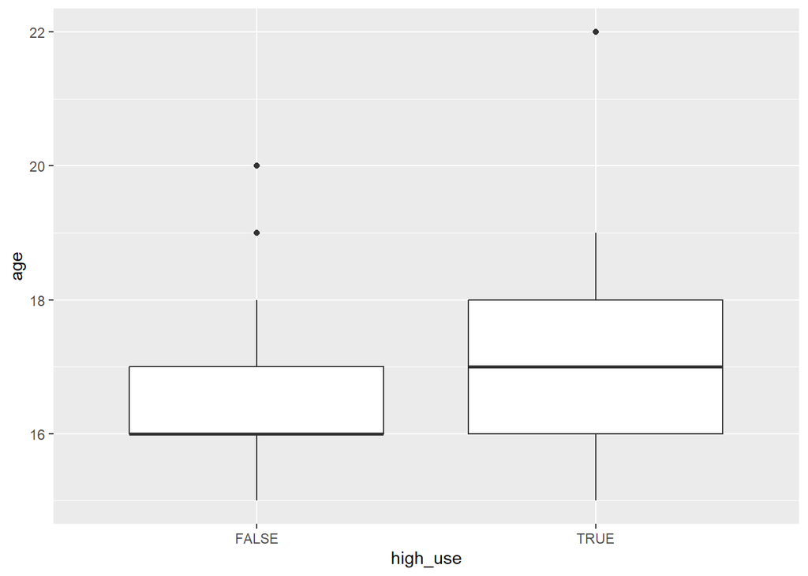

```r
g1 <- ggplot(alc, aes(x = high_use, y = age))
g2 <- ggplot(alc, aes(x = high_use, y = G3))
g3 <- ggplot(alc, aes(x = high_use, y = absences))


g1 + geom_boxplot()
```

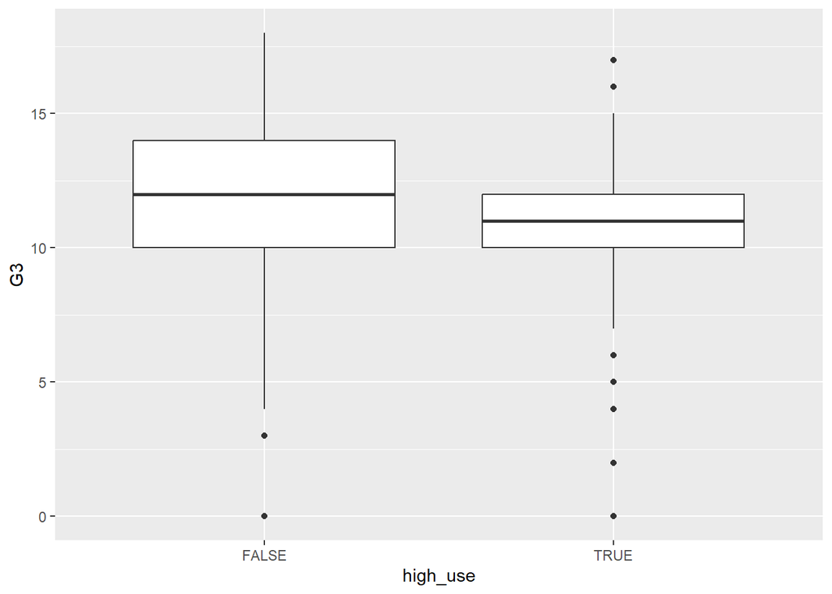

```r
g2 + geom_boxplot()
```

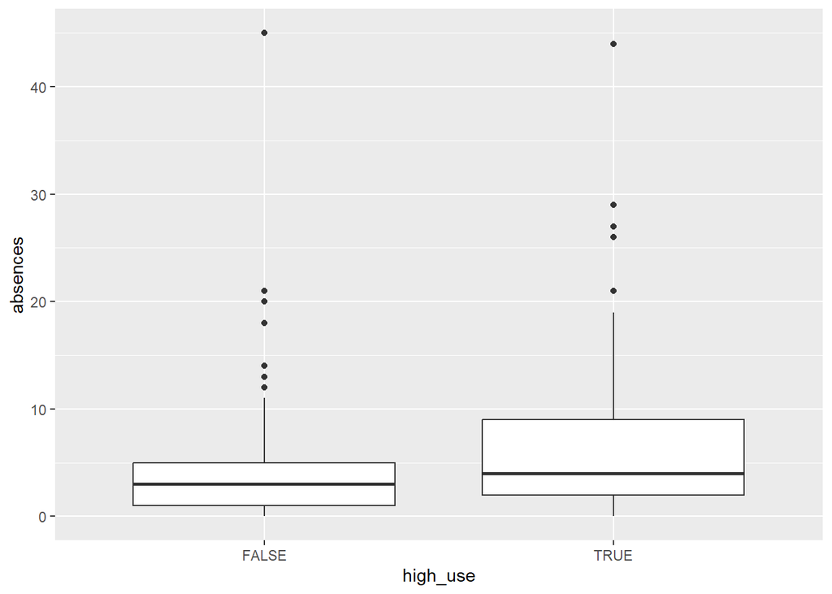

```r
g3 + geom_boxplot()
```

Using tables and boxplots we can assume

- high consumption of alcohol is slightly more common in broken families
- Young people use less alcohol
- People with high grades have smaller alcohol consumption
- people with high alcohol consumption are more often absence

Therefore hypotheses presented seem to be correct.

```r
m <- glm(high_use ~ G3 + absences + age + Pstatus, data = alc, family = "binomial")
summary(m)
```

```
##
## Call:
## glm(formula = high_use ~ G3 + absences + age + Pstatus, family = "binomial",
##     data = alc)
##
## Deviance Residuals:
##     Min       1Q   Median       3Q      Max
## -2.3352  -0.8239  -0.7050   1.2037   1.8781
##
## Coefficients:
##             Estimate Std. Error z value Pr(>|z|)
## (Intercept) -2.52154    1.82438  -1.382 0.166931
## G3          -0.06845    0.03602  -1.900 0.057371 .
## absences     0.08199    0.02335   3.511 0.000446 ***
## age          0.12084    0.10147   1.191 0.233666
## PstatusT     0.05517    0.39732   0.139 0.889572
## ---
## Signif. codes:  0 '***' 0.001 '**' 0.01 '*' 0.05 '.' 0.1 ' ' 1
##
## (Dispersion parameter for binomial family taken to be 1)
##
##     Null deviance: 452.04  on 369  degrees of freedom
## Residual deviance: 428.47  on 365  degrees of freedom
## AIC: 438.47
##
## Number of Fisher Scoring iterations: 4
```

```r
step(m)
```

```
## Start:  AIC=438.47
## high_use ~ G3 + absences + age + Pstatus
##
##            Df Deviance    AIC
## - Pstatus   1   428.49 436.49
## - age       1   429.89 437.89
## <none>          428.47 438.47
## - G3        1   432.09 440.09
## - absences  1   442.85 450.85
##
## Step:  AIC=436.49
## high_use ~ G3 + absences + age
##
##            Df Deviance    AIC
## - age       1   429.93 435.93
## <none>          428.49 436.49
## - G3        1   432.17 438.17
## - absences  1   443.07 449.07
##
## Step:  AIC=435.93
## high_use ~ G3 + absences
##
##            Df Deviance    AIC
## <none>          429.93 435.93
## - G3        1   434.52 438.52
## - absences  1   445.68 449.68
```

```
##
## Call:  glm(formula = high_use ~ G3 + absences, family = "binomial",
##     data = alc)
##
## Coefficients:
## (Intercept)           G3     absences
##    -0.38732     -0.07606      0.08423
##
## Degrees of Freedom: 369 Total (i.e. Null);  367 Residual
## Null Deviance:       452
## Residual Deviance: 429.9     AIC: 435.9
```

In this case such model would have just 2 predictors: *absence and G3*. So let’s create such model.

```r
m <- glm(high_use ~ G3 + absences, data = alc, family = "binomial")
summary(m)
```

```
##
## Call:
## glm(formula = high_use ~ G3 + absences, family = "binomial",
##     data = alc)
##
## Deviance Residuals:
##     Min       1Q   Median       3Q      Max
## -2.3286  -0.8298  -0.7219   1.2113   1.9242
##
## Coefficients:
##             Estimate Std. Error z value Pr(>|z|)
## (Intercept) -0.38732    0.43500  -0.890 0.373259
## G3          -0.07606    0.03553  -2.141 0.032311 *
## absences     0.08423    0.02309   3.648 0.000264 ***
## ---
## Signif. codes:  0 '***' 0.001 '**' 0.01 '*' 0.05 '.' 0.1 ' ' 1
##
## (Dispersion parameter for binomial family taken to be 1)
##
##     Null deviance: 452.04  on 369  degrees of freedom
## Residual deviance: 429.93  on 367  degrees of freedom
## AIC: 435.93
##
## Number of Fisher Scoring iterations: 4
```

So according to he model the astimate for parameter G3 is -0.08, and parameter for absence is 0.084. intercept is -0.39. To calculate odds ratios, we use following command:

```r
OR <- coef(m) %>% exp
OR
```

```
## (Intercept)          G3    absences
##   0.6788751   0.9267616   1.0878762
```

Ratios describe the change of predictable variable if the explainable variable is changed one unit.

```r
CI=confint(m)
CI
```

```
##                   2.5 %       97.5 %
## (Intercept) -1.25260555  0.459482521
## G3          -0.14621889 -0.006471056
## absences     0.04110528  0.131708308
```

This provides 95% confidence intervals. 97.5 being the upper and 2.5 the lower interval.

Hypothesis vise this would mean that age and family status does not have important role on does one consume high amounts of alcohol or not. And that high grades means less alcohol and hing absences is tied to high alcohol consumption. How eve it is unclear which one is the cause and which is the result.

```r
alc = mutate(alc, probability = predict(m, type = "response"))
alc = mutate(alc, prediction =probability>0.5)
table(high_use = alc$high_use, prediction = alc$prediction)%>%prop.table()
```

```
##         prediction
## high_use      FALSE       TRUE
##    FALSE 0.68108108 0.01891892
##    TRUE  0.25675676 0.04324324
```

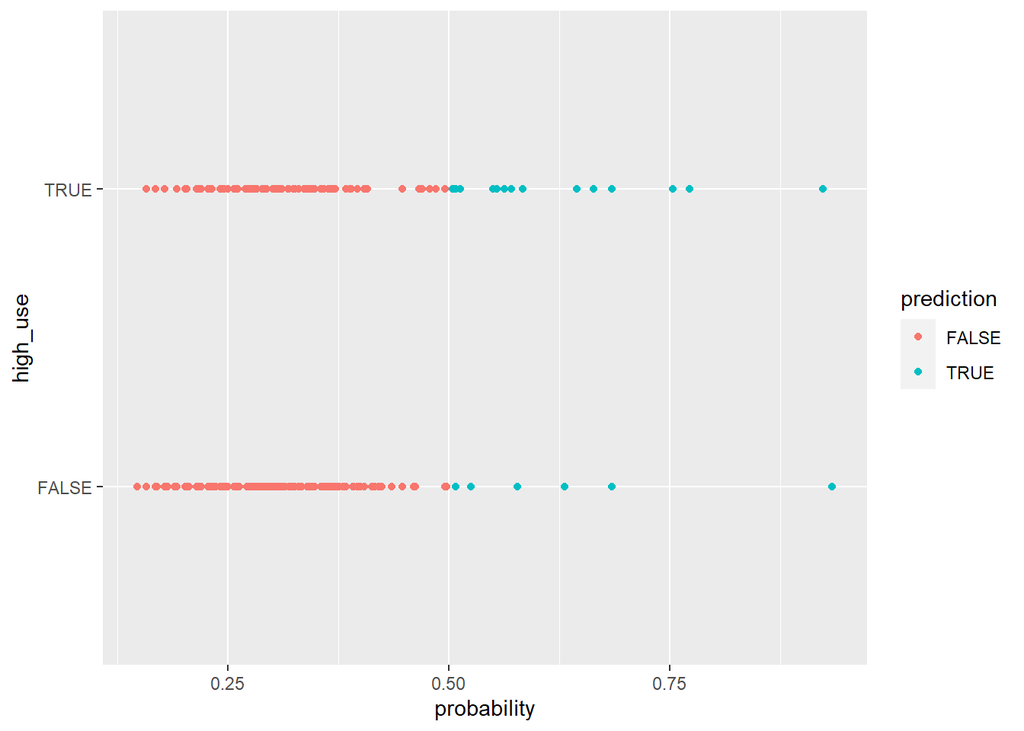

```r
g <- ggplot(alc, aes(x = probability, y = high_use, col=prediction))

# define the geom as points and draw the plot
g+geom_point()
```

The visual representation shows that the model often assumes High use to be false even tough it actually would be true.

```r
loss_func <- function(class, prob) {
  n_wrong <- abs(class - prob) > 0.5
  mean(n_wrong)
}

loss_func(alc$high_use,alc$probability)
```

```
## [1] 0.2756757
```

The training error (the mean number of wrong predictions) is 0,28

```r
library(boot)
cv <- cv.glm(data = alc, cost = loss_func, glmfit = m, K = 10)

# average number of wrong predictions in the cross validation
cv$delta[1]
```

```
## [1] 0.2918919
```

```r
m2 <- glm(high_use ~ G3 + absences+ school + sex + address+ famsize + Pstatus + Medu + Fedu + Mjob + Fjob + reason + guardian + traveltime + studytime + schoolsup+ famsup+ activities + nursery + higher + internet + romantic + famrel + freetime + goout + health + failures + paid + absences + G1 + G2, data = alc, family = "binomial")
summary(m2)
```

```
##
## Call:
## glm(formula = high_use ~ G3 + absences + school + sex + address +
##     famsize + Pstatus + Medu + Fedu + Mjob + Fjob + reason +
##     guardian + traveltime + studytime + schoolsup + famsup +
##     activities + nursery + higher + internet + romantic + famrel +
##     freetime + goout + health + failures + paid + absences +
##     G1 + G2, family = "binomial", data = alc)
##
## Deviance Residuals:
##     Min       1Q   Median       3Q      Max
## -1.7620  -0.6544  -0.3590   0.4831   2.8990
##
## Coefficients:
##                  Estimate Std. Error z value Pr(>|z|)
## (Intercept)      -3.10711    1.79919  -1.727 0.084177 .
## G3                0.05976    0.11463   0.521 0.602121
## absences          0.09105    0.02706   3.365 0.000766 ***
## schoolMS         -0.48058    0.53496  -0.898 0.369001
## sexM              0.84885    0.33281   2.551 0.010755 *
## addressU         -0.85479    0.41943  -2.038 0.041552 *
## famsizeLE3        0.51405    0.33078   1.554 0.120176
## PstatusT         -0.29228    0.53799  -0.543 0.586937
## Medu              0.04021    0.22256   0.181 0.856645
## Fedu              0.14434    0.19799   0.729 0.465991
## Mjobhealth       -1.07147    0.76687  -1.397 0.162353
## Mjobother        -0.85282    0.50337  -1.694 0.090222 .
## Mjobservices     -0.82754    0.58036  -1.426 0.153896
## Mjobteacher      -0.34813    0.70825  -0.492 0.623052
## Fjobhealth        0.33260    1.19154   0.279 0.780142
## Fjobother         0.81603    0.86311   0.945 0.344431
## Fjobservices      1.19959    0.88620   1.354 0.175853
## Fjobteacher      -0.34774    1.04522  -0.333 0.739367
## reasonhome        0.55292    0.39470   1.401 0.161262
## reasonother       1.52294    0.54867   2.776 0.005508 **
## reasonreputation  0.01215    0.41787   0.029 0.976799
## guardianmother   -0.83744    0.37652  -2.224 0.026136 *
## guardianother    -0.13975    0.80413  -0.174 0.862026
## traveltime        0.32446    0.24022   1.351 0.176797
## studytime        -0.27488    0.20833  -1.319 0.187012
```

[output cut: 10 more lines]

```
## health            0.18851    0.11495   1.640 0.101042
## failures          0.33167    0.27916   1.188 0.234790
## paidyes           0.53225    0.32442   1.641 0.100883
## G1               -0.13568    0.12864  -1.055 0.291563
## G2                0.10089    0.15969   0.632 0.527532
## ---
## Signif. codes:  0 '***' 0.001 '**' 0.01 '*' 0.05 '.' 0.1 ' ' 1
##
## (Dispersion parameter for binomial family taken to be 1)
##
##     Null deviance: 452.04  on 369  degrees of freedom
## Residual deviance: 310.30  on 330  degrees of freedom
## AIC: 390.3
##
## Number of Fisher Scoring iterations: 5
```

```r
step(m2)
```

```
## Start:  AIC=390.3
## high_use ~ G3 + absences + school + sex + address + famsize +
##     Pstatus + Medu + Fedu + Mjob + Fjob + reason + guardian +
##     traveltime + studytime + schoolsup + famsup + activities +
##     nursery + higher + internet + romantic + famrel + freetime +
##     goout + health + failures + paid + absences + G1 + G2
##
##              Df Deviance    AIC
## - Mjob        4   314.58 386.58
## - schoolsup   1   310.30 388.30
## - Medu        1   310.33 388.33
## - internet    1   310.34 388.34
## - famsup      1   310.35 388.35
## - higher      1   310.47 388.47
## - G3          1   310.57 388.57
## - Pstatus     1   310.59 388.59
## - G2          1   310.70 388.70
## - Fedu        1   310.83 388.83
## - Fjob        4   317.06 389.06
## - school      1   311.12 389.12
## - G1          1   311.40 389.40
## - failures    1   311.73 389.73
## - nursery     1   311.99 389.99
## - studytime   1   312.08 390.08
## - romantic    1   312.11 390.11
## - traveltime  1   312.14 390.14
## <none>            310.30 390.30
## - famsize     1   312.70 390.70
## - paid        1   313.03 391.03
## - health      1   313.05 391.05
## - freetime    1   313.44 391.44
## - guardian    2   315.67 391.67
## - activities  1   313.75 391.75
## - address     1   314.45 392.45
## - reason      3   319.54 393.54
## - sex         1   316.96 394.96
## - absences    1   321.59 399.59
## - famrel      1   322.20 400.20
## - goout       1   350.56 428.56
##
```

[output cut: 492 more lines]

```
##              Df Deviance    AIC
## <none>            329.01 363.01
## - famsize     1   331.20 363.20
## - romantic    1   331.25 363.25
## - reason      3   335.60 363.60
## - activities  1   331.61 363.61
## - health      1   331.97 363.97
## - studytime   1   332.12 364.12
## - paid        1   332.59 364.59
## - guardian    2   335.95 365.95
## - address     1   336.70 368.70
## - sex         1   338.10 370.10
## - famrel      1   338.76 370.76
## - absences    1   343.00 375.00
## - goout       1   382.34 414.34
```

```
##
## Call:  glm(formula = high_use ~ absences + sex + address + famsize +
##     reason + guardian + studytime + activities + romantic + famrel +
##     goout + health + paid, family = "binomial", data = alc)
##
## Coefficients:
##      (Intercept)          absences              sexM          addressU
##         -1.72681           0.09174           0.91034          -0.94771
##       famsizeLE3        reasonhome       reasonother  reasonreputation
##          0.45183           0.20790           1.02210          -0.27714
##   guardianmother     guardianother         studytime     activitiesyes
##         -0.75088           0.40855          -0.32528          -0.46361
##      romanticyes            famrel             goout            health
##         -0.45457          -0.48800           0.90858           0.17681
##          paidyes
##          0.54838
##
## Degrees of Freedom: 369 Total (i.e. Null);  353 Residual
## Null Deviance:       452
## Residual Deviance: 329   AIC: 363
```

```r
m3 <- glm(high_use ~ absences + sex + address + famsize +
    reason + guardian + studytime + activities + romantic + famrel +
    goout + health + paid, data = alc, family = "binomial")
summary(m3)
```

```
##
## Call:
## glm(formula = high_use ~ absences + sex + address + famsize +
##     reason + guardian + studytime + activities + romantic + famrel +
##     goout + health + paid, family = "binomial", data = alc)
##
## Deviance Residuals:
##     Min       1Q   Median       3Q      Max
## -1.8674  -0.7171  -0.4029   0.5821   2.7665
##
## Coefficients:
##                  Estimate Std. Error z value Pr(>|z|)
## (Intercept)      -1.72681    0.94633  -1.825 0.068041 .
## absences          0.09174    0.02432   3.773 0.000161 ***
## sexM              0.91034    0.30568   2.978 0.002901 **
## addressU         -0.94771    0.34320  -2.761 0.005756 **
## famsizeLE3        0.45183    0.30426   1.485 0.137536
## reasonhome        0.20790    0.36585   0.568 0.569858
## reasonother       1.02210    0.48846   2.093 0.036393 *
## reasonreputation -0.27714    0.37752  -0.734 0.462877
## guardianmother   -0.75088    0.33290  -2.256 0.024096 *
## guardianother     0.40855    0.73349   0.557 0.577533
## studytime        -0.32528    0.18830  -1.727 0.084081 .
## activitiesyes    -0.46361    0.28927  -1.603 0.109002
## romanticyes      -0.45457    0.30736  -1.479 0.139160
## famrel           -0.48800    0.15813  -3.086 0.002028 **
## goout             0.90858    0.13835   6.567 5.13e-11 ***
## health            0.17681    0.10399   1.700 0.089096 .
## paidyes           0.54838    0.29252   1.875 0.060834 .
## ---
## Signif. codes:  0 '***' 0.001 '**' 0.01 '*' 0.05 '.' 0.1 ' ' 1
##
## (Dispersion parameter for binomial family taken to be 1)
##
##     Null deviance: 452.04  on 369  degrees of freedom
## Residual deviance: 329.01  on 353  degrees of freedom
## AIC: 363.01
##
## Number of Fisher Scoring iterations: 5
```

```r
alc2 = mutate(alc, probability = predict(m3, type = "response"))
alc = mutate(alc, prediction =probability>0.5)
loss_func <- function(class, prob) {
  n_wrong <- abs(class - prob) > 0.5
  mean(n_wrong)
}
loss_func(alc$high_use,alc$probability)
```

```
## [1] 0.2756757
```

```r
cv <- cv.glm(data = alc, cost = loss_func, glmfit = m, K = 10)
cv$delta[1]
```

```
## [1] 0.2918919
```